# Turf-grass Growth by Irrigation

# Cynodon analysis

```r
#Create separate data sets per species
TurfGrassData_Cynodon <- TurfGrassData[193:384,1:13]
TurfGrassData_Cynodon$Irrigation <-
  as.character(TurfGrassData_Cynodon$Irrigation)
TurfGrassData_Cynodon$Irrigation <-
  factor(TurfGrassData_Cynodon$Irrigation, levels = c("5","15","20","25"),ordered = T)
TurfGrassData_Cynodon$Date <- as.Date(TurfGrassData_Cynodon$Date, format = "%d-%b")
TurfGrassData_Cynodon <- TurfGrassData_Cynodon %>%
  mutate(Month = month(Date, label = TRUE))
TurfGrassData_Cynodon <- TurfGrassData_Cynodon %>%
  mutate(IrrigationMonth = paste(Irrigation, Month, sep = "mm_"))
dim(TurfGrassData_Cynodon)
```

```
[1] 192  15
```

```r
TurfGrassData_Cynodon$IrrigationMonth <-
  factor(TurfGrassData_Cynodon$IrrigationMonth,
         levels = c("5mm_Feb","15mm_Feb","20mm_Feb","25mm_Feb",
                    "5mm_Mar","15mm_Mar","20mm_Mar","25mm_Mar",
                    "5mm_Apr","15mm_Apr","20mm_Apr","25mm_Apr",
                    "5mm_May","15mm_May","20mm_May","25mm_May"),ordered = T)
#View(TurfGrassData_Cynodon)
```

## Removal of outliers

```r
#rownames(TurfGrassData_Cynodon)
#boxplot(TurfGrassData_Cynodon$Dry.weight)
#boxplot(TurfGrassData_Cynodon$Wet.weight)
#boxplot(TurfGrassData_Cynodon$Height)

 TurfGrassData_Cynodon_feb <- TurfGrassData_Cynodon %>%
   filter(Month == "Feb")
#View(TurfGrassData_Cynodon_feb)
# boxplot(TurfGrassData_Cynodon_feb$Dry.weight)
 grubbs.test(TurfGrassData_Cynodon_feb$Dry.weight, two.sided = T, type = 10)
```

```
    Grubbs test for one outlier

data:  TurfGrassData_Cynodon_feb$Dry.weight
G = 3.03565, U = 0.72919, p-value = 0.04103
alternative hypothesis: highest value 5.75 is an outlier
```

```r
 TurfGrassData_Cynodon <- TurfGrassData_Cynodon %>%
   filter(row.names(TurfGrassData_Cynodon) != "C_16-Feb_15_S2")
 "C_16-Feb_15_S2" %in% rownames(TurfGrassData_Cynodon)
```

```
[1] FALSE
```

```r
# boxplot(TurfGrassData_Cynodon_feb$Height)
 grubbs.test(TurfGrassData_Cynodon_feb$Height, two.sided = T, type = 10)
```

```
    Grubbs test for one outlier

data:  TurfGrassData_Cynodon_feb$Height
G = 3.4638, U = 0.6474, p-value = 0.004849
alternative hypothesis: highest value 5 is an outlier
```

```r
 TurfGrassData_Cynodon <- TurfGrassData_Cynodon %>%
   filter(row.names(TurfGrassData_Cynodon) != "C_09-Feb_20_S2")
 "C_09-Feb_20_S2" %in% rownames(TurfGrassData_Cynodon)
```

```
[1] FALSE
```

```r
 TurfGrassData_Cynodon_Mar <- TurfGrassData_Cynodon %>%
   filter(Month == "Mar")
 #boxplot(TurfGrassData_Cynodon_Mar$Dry.weight)
 grubbs.test(TurfGrassData_Cynodon_Mar$Dry.weight, two.sided = T, type = 10)
```

```
    Grubbs test for one outlier

data:  TurfGrassData_Cynodon_Mar$Dry.weight
G = 3.064, U = 0.796, p-value = 0.06103
alternative hypothesis: highest value 8.036 is an outlier
```

```r
# TurfGrassData_Cynodon <- TurfGrassData_Cynodon %>%
#   filter(row.names(TurfGrassData_Cynodon) != "C_01-Mar_25_S1")
# "C_01-Mar_25_S1" %in% rownames(TurfGrassData_Cynodon)
#
 TurfGrassData_Cynodon_Apr <- TurfGrassData_Cynodon %>%
   filter(Month == "Apr")
# boxplot(TurfGrassData_Cynodon_Apr$Dry.weight)
# View(TurfGrassData_Cynodon_Apr)
 grubbs.test(TurfGrassData_Cynodon_Apr$Wet.weight, two.sided = T, type = 10)
```

```
    Grubbs test for one outlier

data:  TurfGrassData_Cynodon_Apr$Wet.weight
G = 3.0730, U = 0.7948, p-value = 0.05879
alternative hypothesis: highest value 32.041 is an outlier
```

```r
 TurfGrassData_Cynodon <- TurfGrassData_Cynodon %>%
   filter(row.names(TurfGrassData_Cynodon) != "C_05-Apr_25_S2")
 "C_05-Apr_25_S2" %in% rownames(TurfGrassData_Cynodon)
```

```
[1] FALSE
```

```r
 TurfGrassData_Cynodon <- TurfGrassData_Cynodon %>%
   filter(row.names(TurfGrassData_Cynodon) != "C_19-Apr_25_S1")
 "C_19-Apr_25_S1" %in% rownames(TurfGrassData_Cynodon)
```

```
[1] FALSE
```

```r
 TurfGrassData_Cynodon_May <- TurfGrassData_Cynodon %>%
   filter(Month == "May")
# boxplot(TurfGrassData_Cynodon_May$Dry.weight)
# View(TurfGrassData_Cynodon_May)
 grubbs.test(TurfGrassData_Cynodon_May$Dry.weight, two.sided = T, type = 11)
```

```
    Grubbs test for two opposite outliers

data:  TurfGrassData_Cynodon_May$Dry.weight
G = 3.76838, U = 0.87582, p-value < 2.2e-16
alternative hypothesis: 0.501 and 3.849 are outliers
```

```r
 TurfGrassData_Cynodon <- TurfGrassData_Cynodon %>%
   filter(row.names(TurfGrassData_Cynodon) != "C_24-May_15_S2")
 "C_24-May_15_S2" %in% rownames(TurfGrassData_Cynodon)
```

```
[1] FALSE
```

```r
TurfGrassData_Cynodon <- TurfGrassData_Cynodon %>%
   filter(row.names(TurfGrassData_Cynodon) != "C_24-May_15_S2")
 "C_24-May_15_S2" %in% rownames(TurfGrassData_Cynodon)
```

```
[1] FALSE
```

```r
TurfGrassData_Cynodon <- TurfGrassData_Cynodon %>%
   filter(row.names(TurfGrassData_Cynodon) != "C_17-May_5_S2")
 "C_17-May_5_S2" %in% rownames(TurfGrassData_Cynodon)
```

```
[1] FALSE
```

```r
 #
# TurfGrassData_Cynodon_May <- TurfGrassData_Cynodon %>%
#   filter(Month == "May")
# #boxplot(TurfGrassData_Cynodon_May$Dry.weight)
# grubbs.test(TurfGrassData_Cynodon_May$Dry.weight, two.sided = T, type = 10)
#dim(TurfGrassData_Cynodon)

#View(TurfGrassData_Cynodon)
```

# Regression analysis

When two or more independent variables are highly correlated, it can lead to multicollinearity in your regression model. This can make it difficult to determine the individual effect of each variable on the dependent variable. However, whether to include both variables depends on the context and the degree of correlation. When dealing with multiple independent variables that could be correlated, it’s important to assess the correlations among all pairs of variables.

```r
# Calculate correlation matrix
# Check  the data types of the columns:
sapply(TurfGrassData_Cynodon[, c(3, 5:12)], class)
```

```
$Irrigation
[1] "ordered" "factor"

$Wet.weight
[1] "numeric"

$Dry.weight
[1] "numeric"

$Height
[1] "numeric"

$Soil.moisture
[1] "numeric"

$Rainfall
[1] "numeric"

$Total.precipitation
[1] "numeric"

$Temperature
[1] "numeric"

$HR2PM
[1] "numeric"
```

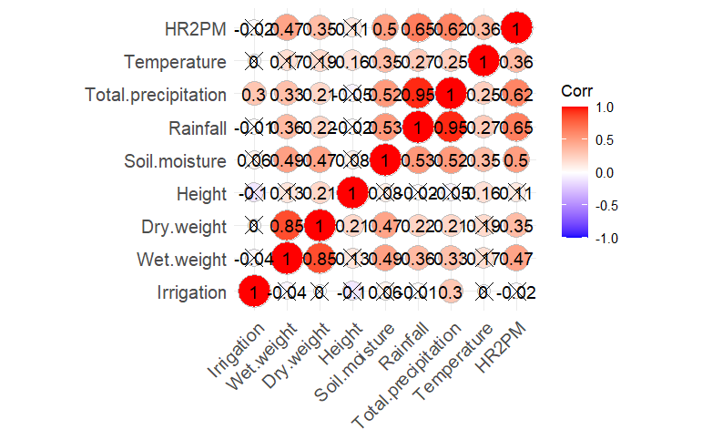

```r
# Convert non-numeric columns to numeric (if they are actually numeric but stored as factors or characters)
TurfGrassData_Cynodon[, c(3, 5:12)] <- lapply(TurfGrassData_Cynodon[, c(3, 5:12)], function(x) as.numeric(as.character(x)))

# Recalculate the correlation matrix:
cor_matrix <- cor(TurfGrassData_Cynodon[, c(3, 5:12)])

# Function to calculate p-values
cor_test <- function(x) {
  FUN <- function(x, y) cor.test(x, y)[["p.value"]]
  z <- outer(
    colnames(x), colnames(x),
    Vectorize(function(i, j) FUN(x[, i], x[, j]))
  )
  dimnames(z) <- list(colnames(x), colnames(x))
  z
}

# Compute correlation matrix
cor_matrix <- cor(TurfGrassData_Cynodon[, c(3, 5:12)], use = "complete.obs")

# Compute p-values matrix
p_matrix <- cor_test(TurfGrassData_Cynodon[, c(3, 5:12)])

# Plot the correlation matrix with p-values
ggcorrplot(cor_matrix, method = "circle", lab = TRUE, p.mat = p_matrix, sig.level = 0.05)
```

```r
NA
NA
```

Correlation coefficients as circles. Crossed out values for correlations that are not statistically significant (p-values > 0.05).

# Interpreting the Correlation Matrix

Correlation Coefficients: The matrix shows the correlation coefficients for each pair of variables. High absolute values (e.g., |correlation| > 0.7) indicate strong correlations. Low absolute values indicate weak correlations.

# Deciding Which Variables to Exclude

High Correlation: If two variables are highly correlated, consider excluding one of them. Domain Knowledge: Use your understanding of the subject matter to decide which variable is more relevant. Variance Inflation Factor (VIF): Calculate VIF to quantify the severity of multicollinearity.

# Linear models that explain the variances of dependent variables

```r
model <- lm(Dry.weight ~ Irrigation + Rainfall, data = TurfGrassData_Cynodon[, c(3, 5:13)])
print(model)
```

```
Call:
lm(formula = Dry.weight ~ Irrigation + Rainfall, data = TurfGrassData_Cynodon[,
    c(3, 5:13)])

Coefficients:
(Intercept)   Irrigation     Rainfall
   2.245673     0.005321     0.020565
```

```r
summary(model)
```

```
Call:
lm(formula = Dry.weight ~ Irrigation + Rainfall, data = TurfGrassData_Cynodon[,
    c(3, 5:13)])

Residuals:
    Min      1Q  Median      3Q     Max
-3.5454 -1.2134 -0.5300  0.6261  8.8049

Coefficients:
            Estimate Std. Error t value Pr(>|t|)
(Intercept) 2.245673   0.363227   6.183 4.01e-09 ***
Irrigation  0.005321   0.019328   0.275  0.78340
Rainfall    0.020565   0.006373   3.227  0.00148 **
---
Signif. codes:  0 '***' 0.001 '**' 0.01 '*' 0.05 '.' 0.1 ' ' 1

Residual standard error: 1.952 on 183 degrees of freedom
Multiple R-squared:  0.05416,   Adjusted R-squared:  0.04383
F-statistic:  5.24 on 2 and 183 DF,  p-value: 0.006125
```

```r
model1 <- lm(Wet.weight ~ Irrigation + Rainfall, data = TurfGrassData_Cynodon[, c(3, 5:13)])
print(model1)
```

```
Call:
lm(formula = Wet.weight ~ Irrigation + Rainfall, data = TurfGrassData_Cynodon[,
    c(3, 5:13)])

Coefficients:
(Intercept)   Irrigation     Rainfall
     4.8729      -0.0134       0.0824
```

```r
summary(model1)
```

```
Call:
lm(formula = Wet.weight ~ Irrigation + Rainfall, data = TurfGrassData_Cynodon[,
    c(3, 5:13)])

Residuals:
   Min     1Q Median     3Q    Max
-8.731 -2.776 -1.228  1.370 24.170

Coefficients:
            Estimate Std. Error t value Pr(>|t|)
(Intercept)  4.87286    0.86833   5.612 7.31e-08 ***
Irrigation  -0.01340    0.04620  -0.290    0.772
Rainfall     0.08240    0.01524   5.409 1.97e-07 ***
---
Signif. codes:  0 '***' 0.001 '**' 0.01 '*' 0.05 '.' 0.1 ' ' 1

Residual standard error: 4.667 on 183 degrees of freedom
Multiple R-squared:  0.1382,    Adjusted R-squared:  0.1288
F-statistic: 14.68 on 2 and 183 DF,  p-value: 1.227e-06
```

```r
model2 <- lm(Height ~ Irrigation + Rainfall, data = TurfGrassData_Cynodon[, c(3, 5:13)])
print(model2)
```

```
Call:
lm(formula = Height ~ Irrigation + Rainfall, data = TurfGrassData_Cynodon[,
    c(3, 5:13)])

Coefficients:
(Intercept)   Irrigation     Rainfall
   1.882929    -0.005044    -0.001495
```

```r
summary(model2)
```

```
Call:
lm(formula = Height ~ Irrigation + Rainfall, data = TurfGrassData_Cynodon[,
    c(3, 5:13)])

Residuals:
    Min      1Q  Median      3Q     Max
-1.3577 -0.3546 -0.1732  0.2988  1.7243

Coefficients:
             Estimate Std. Error t value Pr(>|t|)
(Intercept)  1.882929   0.120832  15.583   <2e-16 ***
Irrigation  -0.005044   0.006430  -0.784    0.434
Rainfall    -0.001495   0.002120  -0.705    0.482
---
Signif. codes:  0 '***' 0.001 '**' 0.01 '*' 0.05 '.' 0.1 ' ' 1

Residual standard error: 0.6494 on 183 degrees of freedom
Multiple R-squared:  0.006015,  Adjusted R-squared:  -0.004848
F-statistic: 0.5537 on 2 and 183 DF,  p-value: 0.5758
```

```r
model3 <- lm(Height ~ Irrigation + Temperature, data = TurfGrassData_Cynodon[, c(3, 5:13)])
print(model3)
```

```
Call:
lm(formula = Height ~ Irrigation + Temperature, data = TurfGrassData_Cynodon[,
    c(3, 5:13)])

Coefficients:
(Intercept)   Irrigation  Temperature
   1.229825    -0.004953     0.033131
```

```r
summary(model3)
```

```
Call:
lm(formula = Height ~ Irrigation + Temperature, data = TurfGrassData_Cynodon[,
    c(3, 5:13)])

Residuals:
    Min      1Q  Median      3Q     Max
-1.3568 -0.4676 -0.0593  0.4236  1.5462

Coefficients:
             Estimate Std. Error t value Pr(>|t|)
(Intercept)  1.229825   0.227665   5.402 2.03e-07 ***
Irrigation  -0.004953   0.006270  -0.790  0.43059
Temperature  0.033131   0.010497   3.156  0.00187 **
---
Signif. codes:  0 '***' 0.001 '**' 0.01 '*' 0.05 '.' 0.1 ' ' 1

Residual standard error: 0.6333 on 183 degrees of freedom
Multiple R-squared:  0.05477,   Adjusted R-squared:  0.04444
F-statistic: 5.302 on 2 and 183 DF,  p-value: 0.005776
```

```r
#Testing if the Dry.weight data is normally distributed
shapiro.test(TurfGrassData_Cynodon$Dry.weight)
```

```
    Shapiro-Wilk normality test

data:  TurfGrassData_Cynodon$Dry.weight
W = 0.81156, p-value = 3.11e-14
```

```r
#histogram(TurfGrassData_Cynodon$Dry.weight)

# Transformations in an attempt to improve normality
# Log transform
TurfGrassData_Cynodon$Dry.weight_log <- log2(max(TurfGrassData_Cynodon$Dry.weight + 1) - TurfGrassData_Cynodon$Dry.weight)
shapiro.test(TurfGrassData_Cynodon$Dry.weight_log)
```

```
    Shapiro-Wilk normality test

data:  TurfGrassData_Cynodon$Dry.weight_log
W = 0.56207, p-value < 2.2e-16
```

```r
#histogram(TurfGrassData_Cynodon$Dry.weight_log)

# Square root transfor
TurfGrassData_Cynodon$Dry.weight_sqrt <- sqrt(max(TurfGrassData_Cynodon$Dry.weight + 1) - TurfGrassData_Cynodon$Dry.weight)
shapiro.test(TurfGrassData_Cynodon$Dry.weight_sqrt)
```

```
    Shapiro-Wilk normality test

data:  TurfGrassData_Cynodon$Dry.weight_sqrt
W = 0.70697, p-value < 2.2e-16
```

```r
#histogram(TurfGrassData_Cynodon$Dry.weight_sqrt)

# Cube root transform
TurfGrassData_Cynodon$Dry.weight_cube <- (max(TurfGrassData_Cynodon$Dry.weight + 1) - TurfGrassData_Cynodon$Dry.weight)^(1/3)
shapiro.test(TurfGrassData_Cynodon$Dry.weight_cube)
```

```
    Shapiro-Wilk normality test

data:  TurfGrassData_Cynodon$Dry.weight_cube
W = 0.66281, p-value < 2.2e-16
```

```r
#histogram(TurfGrassData_Cynodon$Dry.weight_cube)

# Quarter root transform
TurfGrassData_Cynodon$Dry.weight_quarter <- (max(TurfGrassData_Cynodon$Dry.weight + 1) - TurfGrassData_Cynodon$Dry.weight)^(1/4)
shapiro.test(TurfGrassData_Cynodon$Dry.weight_quarter)
```

```
    Shapiro-Wilk normality test

data:  TurfGrassData_Cynodon$Dry.weight_quarter
W = 0.63905, p-value < 2.2e-16
```

```r
#histogram(TurfGrassData_Cynodon$Dry.weight_quarter)
```